# Bay of Biscay and the Iberian Coast

#### Figure 2

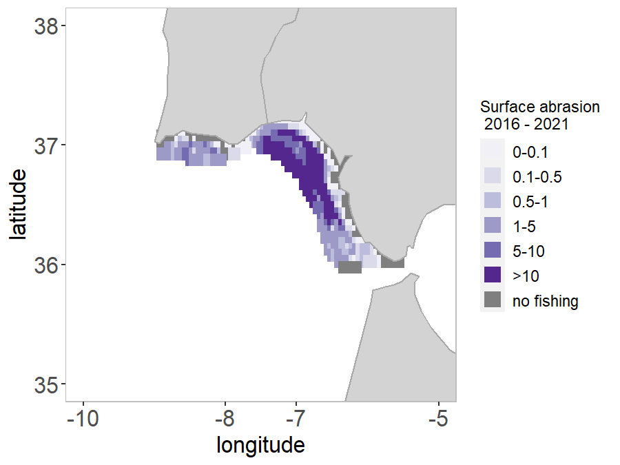

**Figure 2 Surface abrasion, Swept Area Ratio, by mobile bottom-contacting gears (year-1), averaged for the 2016-2021 six-year cycle**

#### Table 2

Table 2 Overview of pressure indicators of all mobile bottom-contacting gears per broad-scale habitat averaged for 2016-2021. I refers to the indicators in Table 1.

| MSFD broad habitat type | Extent of habitat (1000 km<sup>2</sup>) | Number of grid cells | Landings 1000 tonnes | Value 10<sup>6</sup> euro | Swept area 1000 km<sup>2</sup> | Average intensity (I-1) | Prop. of area in fished grid cells (I-2) | Prop. of area fished per year (I-3) | Smallest prop. of area with 90% of fishing effort (I-4) |
| --- | --- | --- | --- | --- | --- | --- | --- | --- | --- |
| Circalittoral mud | 2.37 | 220 | NA | NA | 25.15 | 10.63 | 0.90 | 0.78 | 0.30 |
| Offshore circalittoral mud | 2.12 | 137 | NA | NA | 21.09 | 9.93 | 0.96 | 0.91 | 0.42 |
| Circalittoral sand | 1.96 | 214 | NA | NA | 10.97 | 5.60 | 0.93 | 0.68 | 0.18 |
| Circalittoral mixed sediment | 0.37 | 72 | NA | NA | 2.15 | 5.75 | 0.83 | 0.65 | 0.22 |
| Offshore circalittoral mixed sediment | 0.07 | 26 | NA | NA | 1.32 | 19.31 | 1.00 | 0.98 | 0.35 |
| Offshore circalittoral sand | 0.60 | 41 | NA | NA | 0.87 | 1.47 | 0.84 | 0.75 | 0.49 |
| Infralittoral sand | 0.82 | 159 | NA | NA | 0.67 | 0.81 | 0.63 | 0.20 | 0.09 |
| Upper bathyal sediment | 0.04 | 18 | NA | NA | 0.42 | 10.91 | 0.83 | 0.83 | 0.28 |
| Circalittoral coarse sediment | 0.10 | 32 | NA | NA | 0.33 | 3.27 | 0.99 | 0.84 | 0.31 |
| Infralittoral mixed sediment | 0.17 | 37 | NA | NA | 0.28 | 1.62 | 0.88 | 0.38 | 0.16 |
| Offshore circalittoral coarse sediment | 0.07 | 12 | NA | NA | 0.22 | 3.02 | 1.00 | 0.71 | 0.33 |
| Circalittoral rock and biogenic reef | 0.19 | 112 | NA | NA | 0.21 | 1.12 | 0.80 | 0.44 | 0.21 |
| Infralittoral coarse sediment | 0.11 | 30 | NA | NA | 0.16 | 1.45 | 0.95 | 0.40 | 0.17 |
| Infralittoral mud | 0.19 | 74 | NA | NA | 0.11 | 0.58 | 0.59 | 0.31 | 0.14 |
| Offshore circalittoral rock and biogenic reef | 0.02 | 39 | NA | NA | 0.05 | 2.49 | 0.94 | 0.74 | 0.36 |
| Infralittoral rock and biogenic reef | 0.26 | 88 | NA | NA | 0.03 | 0.10 | 0.49 | 0.09 | 0.19 |
| Unknown | 0.01 | 43 | NA | NA | 0.00 | 0.08 | 0.78 | 0.08 | 0.07 |

#### Figure 3

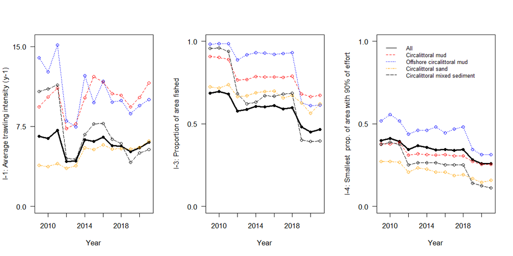

**Figure 3. Time series of (a) mean fishing intensity (surface abrasion), (b) proportion of the surface area of the seafloor fished, (c) aggregation of fishing (proportion of the surface area with 90% of the fishing effort) by habitat. Results represent vessels over 15m (2009-2011) and vessels over 12m (2012-2021).**

#### Figure 4

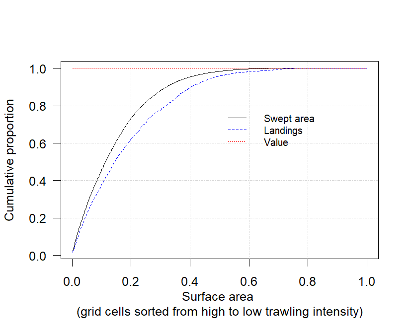

**Figure 4. Cumulative proportion of the swept area, landings and value. Grid cells were sorted from highest to lowest fishing intensity and include non-fished cells. The results are for all mobile bottom-contacting gears based on averaged fishing data per c-square from 2016-2021.**

### Core fishing grounds

No information available

### Fishing by métier

Intensity, weight and value of landings are estimated for the grid cells that were fished by one MBCG métier, ignoring cells fished by other métiers (Table 3).

The métier with the highest landings and value per area fished is the dredge fishery for clams (DRB_MOL). The otter trawls that target crustaceans (OT_CRU) have the lowest landings and value per area fished.

#### Table 3

Table 3. Overview of area fished (sum of swept area), landings and value for the different metiers. Area fished in 1000 km2, weight of landings in 1000 tonnes, value of landings in 10^6 euro.

|  | DRB_MOL | OT_CRU | OT_DMF | OT_MI | OT_SPF | SDN_DMF | SSC_DMF | TBB_CRU | TBB_DMF | TBB_MOL |
| --- | --- | --- | --- | --- | --- | --- | --- | --- | --- | --- |
| Area swept (1000 km2) | 0.01 | 62.99 | 0.64 | 0.49 | 0 | 0 | 0 | 0 | 0 | 0 |
| Landings (1000 tonnes) | NA | NA | NA | NA | NA | NA | NA | NA | NA | NA |
| Value (10^6 euro) | 0.00 | 0.00 | 0.00 | 0.00 | 0 | 0 | 0 | 0 | 0 | 0 |
| Landings (1000 tonnes)/Area swept (1000 km2) | 6.27 | 0.06 | 0.08 | 0.10 | NA | NA | NA | NA | NA | NA |
| Value (10^6 euro)/Area swept (1000 km2) | NA | NA | NA | NA | NA | NA | NA | NA | NA | NA |

### Impact

No information available

### Management scenarios

No information available on value/weight of landings.

#### Overview all MSFD habitats

Fishing effort consequences, as a % relative to total swept area, of protecting a certain fraction of each broad habitat type sorted from low to high fished c-squares

| MSFD broad habitat type | Extent of habitat 1000 km<sup>2</sup> | 0.05 | 0.1 | 0.2 | 0.3 | 0.4 | 0.5 | 0.6 | 0.7 | 0.8 | 0.9 |
| --- | --- | --- | --- | --- | --- | --- | --- | --- | --- | --- | --- |
| Circalittoral mud | 2.37 | 0.0 | <0.1 | <0.1 | 1.7 | 7.4 | 14.3 | 21.9 | 34.7 | 51.1 | 70.4 |
| Offshore circalittoral mud | 2.12 | <0.1 | 0.4 | 2.1 | 4.6 | 8.2 | 14.4 | 24.1 | 36.6 | 53.8 | 73.6 |
| Circalittoral sand | 1.96 | 0.0 | <0.1 | 0.2 | 0.9 | 2.0 | 4.2 | 9.6 | 16.9 | 33.7 | 64.2 |
| Circalittoral mixed sediment | 0.37 | 0.0 | 0.0 | <0.1 | 0.6 | 2.2 | 5.0 | 13.0 | 21.0 | 33.7 | 60.7 |
| Offshore circalittoral mixed sediment | 0.07 | 0.5 | 2.0 | 2.5 | 9.3 | 18.0 | 33.2 | 53.6 | 66.7 | 80.3 | 100.0 |
| Offshore circalittoral sand | 0.6 | 0.0 | 0.0 | 1.7 | 6.4 | 13.3 | 21.6 | 28.4 | 44.5 | 57.7 | 75.4 |
| Infralittoral sand | 0.82 | 0.0 | 0.0 | 0.0 | 0.0 | <0.1 | 0.2 | 0.6 | 1.8 | 6.5 | 15.2 |
| Upper bathyal sediment | 0.04 | 0.0 | 0.0 | 3.1 | 4.0 | 8.5 | 17.5 | 17.5 | 26.0 | 50.7 | 100.0 |
| Circalittoral coarse sediment | 0.1 | 0.3 | 0.3 | 2.8 | 7.6 | 15.7 | 28.7 | 46.5 | 46.5 | 62.4 | 81.0 |
| Infralittoral mixed sediment | 0.17 | 0.0 | 0.0 | <0.1 | <0.1 | 0.1 | 1.1 | 3.9 | 8.4 | 22.2 | 46.1 |
| Offshore circalittoral coarse sediment | 0.07 | 0.2 | 1.0 | 2.5 | 7.4 | 7.4 | 12.3 | 12.3 | 18.4 | 37.7 | 100.0 |
| Circalittoral rock and biogenic reef | 0.19 | 0.0 | 0.0 | <0.1 | 0.2 | 0.9 | 4.8 | 10.0 | 21.6 | 47.5 | 78.1 |
| Infralittoral coarse sediment | 0.11 | 0.0 | 0.1 | 0.3 | 0.7 | 3.6 | 12.2 | 12.2 | 14.9 | 100.0 | 100.0 |
| Infralittoral mud | 0.19 | 0.0 | 0.0 | 0.0 | 0.0 | 0.0 | 0.3 | 1.1 | 10.1 | 37.2 | 76.5 |
| Offshore circalittoral rock and biogenic reef | 0.02 | 0.0 | 0.3 | 2.7 | 8.6 | 11.4 | 20.2 | 33.1 | 33.1 | 47.8 | 70.8 |
| Infralittoral rock and biogenic reef | 0.26 | 0.0 | 0.0 | 0.0 | 0.0 | 0.0 | 0.0 | 1.0 | 3.3 | 17.2 | 36.1 |
| Unknown | 0.01 | 0.0 | 0.0 | 0.0 | 11.4 | 11.4 | 26.2 | 26.2 | 26.2 | 100.0 | 100.0 |